# Fifa 19

## Multivariate Exploration

> Create plots of three or more variables to investigate your data even further. Make sure that your investigations are justified, and follow from your work in the previous sections.

#### will make the value in ranges so we can visualize it correctly

```python
ranges = []
for v in df['Value']:
    if(v >= 10000 and v < 350000):
        ranges.append("superlow")
    elif(v >= 350000 and v < 720000):
        ranges.append('low')
    elif(v >= 720000 and v < 2200000):
        ranges.append('medium')
    elif(v >= 2200000 and v < 10000000):
        ranges.append('high')
    elif(v >= 10000000):
        ranges.append('superhigh')

df['ranges'] = ranges
```

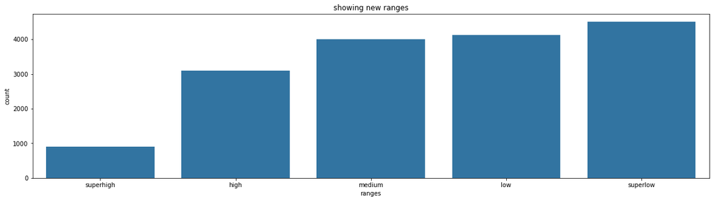

```python
plt.figure(figsize = [20, 5])
base_color = sb.color_palette()[0]
sb.countplot(data=df , x='ranges', color=base_color);
plt.title("showing new ranges")
```

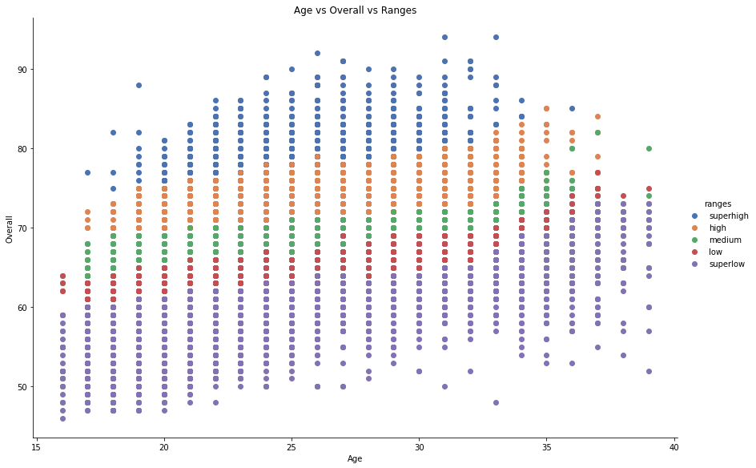

```python
g = sb.FacetGrid(data = df, hue = 'ranges', size = 8, aspect = 1.5,palette="deep")
g.map(plt.scatter, 'Age', 'Overall')
plt.title("Age vs Overall vs Ranges")
g.add_legend();
```

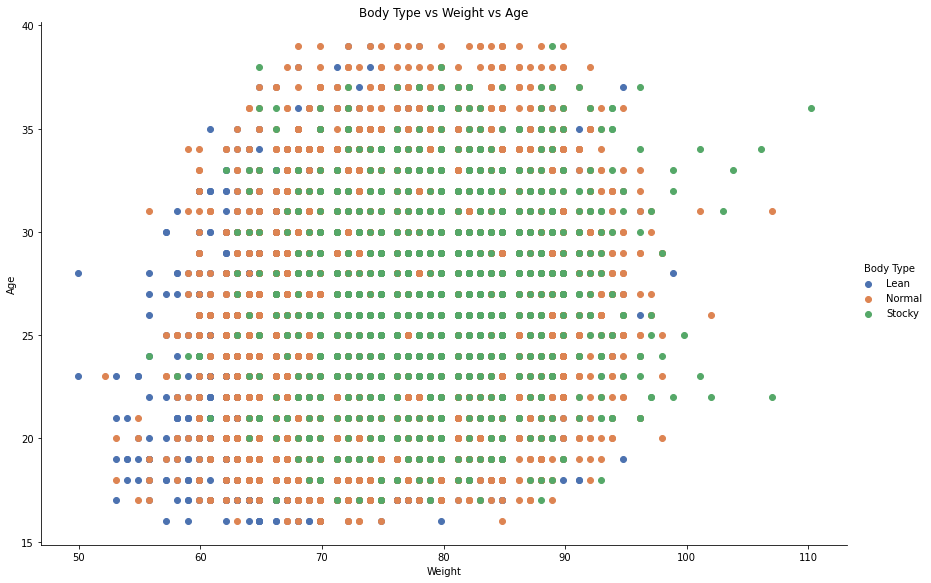

```python
# plotting facet
g = sb.FacetGrid(data = df, hue = 'Body Type', size = 8, aspect = 1.5, palette = 'deep')
g.map(plt.scatter, 'Weight', 'Age')
plt.title("Body Type vs Weight vs Age")
g.add_legend();
```

> Most of the younger players weighs lesser and they also have more of a lean body type.

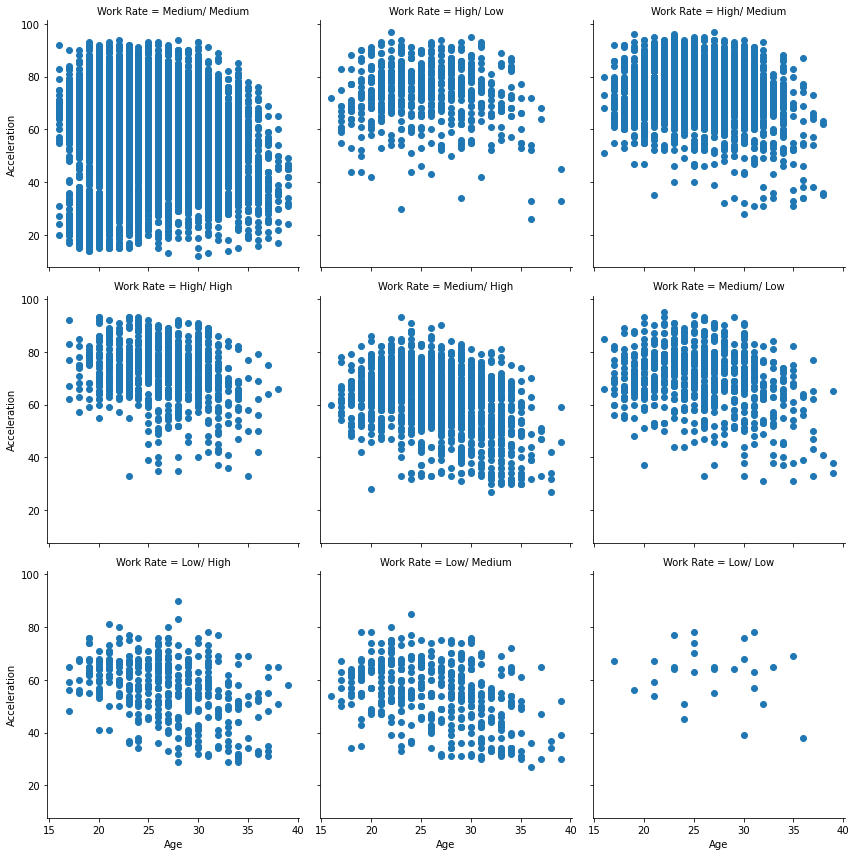

```python
g = sb.FacetGrid(data = df, col = 'Work Rate', col_wrap = 3, size = 4)
g.map(plt.scatter, 'Age', 'Acceleration');
```

> Players whose work rate is High/High, High/Medium have a high acceleration and the Low/Low have a lower acceleration.

### Talking about some of the relationships I observed in this part of the investigation. Were there features that strengthened each other in terms of looking at your feature(s) of interest?

> I focused on making the value in ranges so I can know the players that have the highest ranges what age and overall they have in commman